# Assignment 4, Part II

*Hint:* the relevant column name for population is “assignedPop”.

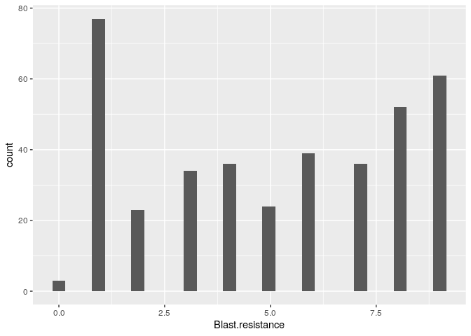

```r
pheno.geno.pca.pop %>%
  ggplot(aes(x=`Blast.resistance`)) +
  geom_histogram()
```

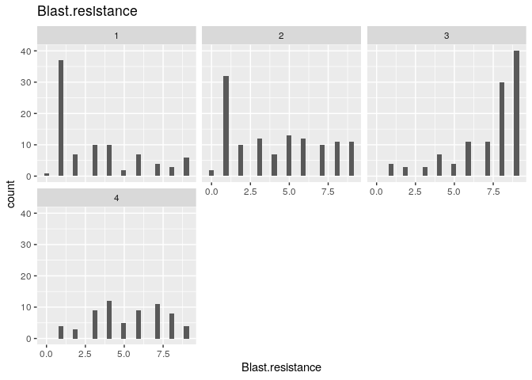

```r
bl <- ggplot(data=pheno.geno.pca.pop, aes(x=`Blast.resistance`)) #create the basic plot object
bl <- bl + geom_histogram() #tell R that we want a histogram, with binwidth of .5
bl <- bl + facet_wrap(facets= ~ assignedPop, ncol=3) # a separate plot ("facet") for each region, arranged in 3 columns
bl <- bl + ggtitle("Blast.resistance") #add a title
bl #display the plot
```

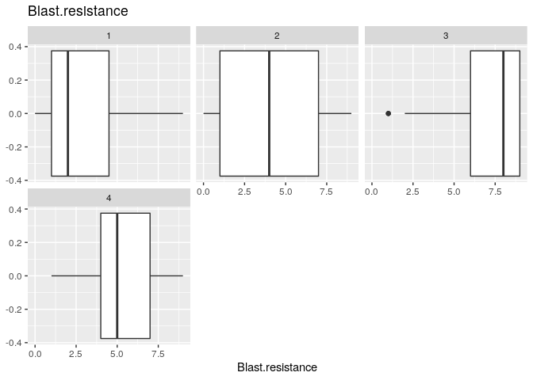

```r
bl2 <- ggplot(data=pheno.geno.pca.pop, aes(x=`Blast.resistance`)) #create the basic plot object
bl2 <- bl2 + geom_boxplot() #tell R that we want a histogram, with binwidth of .5
bl2 <- bl2 + facet_wrap(facets= ~ assignedPop, ncol=3) # a separate plot ("facet") for each region, arranged in 3 columns
bl2 <- bl2 + ggtitle("Blast.resistance") #add a title
bl2 #display the plot
```

```r
#The difference is big and is potentially significant.
```

**Exercise 8:**

- Obtain the mean of your trait for each of the four fastStructure populations.
- Perform an ANOVA for your trait to test if it varies significantly by fastStructure population. Show your code, the ANOVA output, and provide an interpretation.
- Discuss: Do your results suggest a problem for GWAS?

```r
sem <- function(x, na.rm=TRUE) {
  if(na.rm) x <- na.omit(x)
  sd(x)/sqrt(length(x)-1)
}

pheno.geno.pca.pop %>% group_by(assignedPop) %>%
  summarize(mean.bl=mean(Blast.resistance,na.rm=T),
            sem.bl=sem(Blast.resistance)
            ) %>%
  arrange(desc(mean.bl))
```

| assignedPop | mean.bl | sem.bl |
| --- | --- | --- |
| 3 | 7.168142 | 0.2082110 |
| 4 | 5.246154 | 0.2812767 |
| 2 | 4.250000 | 0.2612486 |
| 1 | 3.206897 | 0.2839391 |

```r
aov2 <- aov(Blast.resistance ~ assignedPop,data=pheno.geno.pca.pop) #1-way ANOVA for Amylose.content by Region
summary(aov2)
```

```
##              Df Sum Sq Mean Sq F value Pr(>F)
## assignedPop   3  881.8  293.92   46.07 <2e-16 ***
## Residuals   381 2430.6    6.38
## ---
## Signif. codes:  0 '***' 0.001 '**' 0.01 '*' 0.05 '.' 0.1 ' ' 1
## 28 observations deleted due to missingness
```

```r
#The blast resistance difference among populations are significant, so blast resistance is different among each population, and thus is problem for GWAS.
```

**Exercise 9:** Complete the code below to generate a GM object like the one above. Note that “chr” and “pos” should be numeric. *Hint:* Look at help for the `separate` command. You will need to specify the `into`, `sep`, `convert` and `remove` arguments.

```r
if (!requireNamespace("BiocManager", quietly = TRUE))
    install.packages("BiocManager")
BiocManager::install("multtest")
install.packages("EMMREML")
devtools::install_github("jiabowang/GAPIT3",force=TRUE)
devtools::install_github("YaoZhou89/BLINK")
data.geno <- read_csv("../input/Rice_44K_genotypes.csv.gz",
                      na=c("NA","00"))  %>%
  rename(ID=X1) %>%
  dplyr::select(-`6_17160794_1`)
gtToNumeric <- function(x) {
  x <- as.numeric(as.factor(x))-1 # convert to numeric set base genotype to 0
  x[is.na(x)] <- mean(x, na.rm=TRUE) # fill in missing data. THIS SHOULD BE DONE BETTER!
  if(max(x, na.rm = TRUE)==1)
    return(x*2) # set alternate homozygous to 2 if necessary
  else return(x)
}

#Now apply it to all gt columns
#Base R function "apply" is much faster than using tidyverse functions when you have this many columns
GD <- cbind(data.geno[,1], apply(data.geno[-1], 2, gtToNumeric))

#take a quick look
head(GD[,1:10])
```

|  | ID | 1_13147 | 1_73192 | 1_74969 | 1_75852 | 1_75953 | 1_91016 | 1_146625 | 1_149005 | 1_149754 |
| --- | --- | --- | --- | --- | --- | --- | --- | --- | --- | --- |
| 1 | NSFTV1 | 2 | 2 | 0 | 2 | 2 | 0.0000000 | 0 | 2 | 0 |
| 2 | NSFTV3 | 0 | 0 | 0 | 0 | 0 | 0.1965318 | 0 | 0 | 2 |
| 3 | NSFTV4 | 0 | 0 | 0 | 0 | 0 | 2.0000000 | 0 | 0 | 2 |
| 4 | NSFTV5 | 0 | 0 | 2 | 2 | 0 | 0.0000000 | 2 | 0 | 2 |
| 5 | NSFTV6 | 0 | 0 | 0 | 0 | 0 | 2.0000000 | 0 | 0 | 2 |
| 6 | NSFTV7 | 2 | 2 | 0 | 2 | 2 | 0.0000000 | 0 | 2 | 0 |

```r
# GAPIT is one of the rare cases where tibbles and data frames are not interchangeable
# So be sure to used "data.frame()" rather than "tibble()"
GM <- data.frame(SNP=colnames(GD)[-1]) %>%
  separate(SNP, into = c("chr","pos"), sep = "_", remove = TRUE, convert = FALSE )
GM <- cbind(SNP = colnames(GD)[-1],GM)
head(GM)
```

|  | SNP | chr | pos |
| --- | --- | --- | --- |
| 1 | 1_13147 | 1 | 13147 |
| 2 | 1_73192 | 1 | 73192 |
| 3 | 1_74969 | 1 | 74969 |
| 4 | 1_75852 | 1 | 75852 |
| 5 | 1_75953 | 1 | 75953 |
| 6 | 1_91016 | 1 | 91016 |

Because GAPIT requires a data frame, not a tibble, we convert after selecting the phenotype

Fill in the trait you chose in the code below and run the code. What trait did you pick?

```r
Y <- pheno.geno.pca.pop %>%
  dplyr::select(ID, Blast.resistance) %>%  # remove the "<" and ">"
  as.data.frame()
```

```r
library(GAPIT3)
```